# Farm Card Calculations

[figure not shown]

https://github.com/kcgis/farm-cards

## Outline

1. What's this about?
2. What's a "farm card"?
3. The Process
4. Taking it Further
5. Questions?

# What are we doing here?

What I want from my farm cards tool:

- Accurate
- Simple
- Accessible

# What's a "farm card"?

in accordance with the Farmland Assessment Law, the Illinois Department of Revenue provides the following publication:

[Publication 122: Instructions for Farmland Assessments](https://www2.illinois.gov/rev/research/publications/pubs/Documents/Pub-122.pdf)

TLDR: It's how we generate property values for agricultural parcels

[figure not shown]

*Image credits: IDR Publication 122*

## Individual Soil Weighting Method

Per IDR, there is a 10-step proccedure for assessing farmland:

1. Get legal boundaries and aerial imagery
2. Overlay soil types
3. Using a combination of aerial imagery and on-site inspection, classify landuse areas

Between GIS and the Assessment office, steps 1-3 are already taken care of before we even started this notebook, and are continuously amended as needed throughout the year.

4. Determine acreage of each soil type within each landuse category **<-- That's GIS!**
5. Determine PI ratings for soil types, using IDR reference table as necessary
6. Adjust PI values for slope and erosion
7. Determine EAV per acre of soil/slope/landuse combination based on IDR reference table
8. Calculate assessed value by multiplying EAV with number of acres
9. Subtotal acres and values by soil/slope/landuse
10. Sum by parcel for full assessed value

# Set Up Notebook Environment

## Data Manipulation and Spatial Overlays

```python
import geopandas as gp
import pandas as pd
import numpy as np
```

## Other Modules

```python
# requesting data from the web
import requests

# plotting figures
import matplotlib.pyplot as plt

# working with files
import os

# working with time
from datetime import datetime
```

## A Few Global Variables

```python
# Spatial reference for layers
sr = "{'wkid': 3435}"

# Parcels REST service
parcels_url = 'https://maps.co.kendall.il.us/server/rest/services/Hosted/Current_Cadastral_Features/FeatureServer/1/query?'

# SSURGO Soils REST service
soils_url = 'https://maps.co.kendall.il.us/server/rest/services/Hosted/Assessor_Soils/FeatureServer/0/query?'

# Landuse REST service
landuse_url = 'https://maps.co.kendall.il.us/server/rest/services/Hosted/Assessor_Landuse/FeatureServer/0/query?'

# Prepare output
out_dir = os.path.expanduser('~/')
export_name = f"farms_{datetime.now().strftime('%Y%m%d-%H%M')}"
file = os.path.join(out_dir, f'{export_name}.txt')
```

### Check if File Already Exists

```python
with open(file, 'w') as a:
    a.write('this shouldn''nt be here')
```

```python
if os.path.exists(file):
    print('Output file already exists. Removing!')
    os.remove(file)
print('Good to go!')
```

```
Output file already exists. Removing!
Good to go!
```

# Getting the Data

## Data from an ArcGIS Feature Service

### Define the query parameters:

```python
parcels_params = {
    'where': "pin LIKE '01-06-2%' AND class in ('0011', '0021')",
    'outFields': 'gross_acres, pin',
    'outSR': sr,
    'f': 'geojson'
}
```

### Submit the request:

```python
parcels = requests.get(parcels_url, parcels_params)
```

### Read Response into GeoDataFrame

`geopandas` is capable of reading GeoJSON and JSON directly and identifying any spatial components.

```python
p_df = gp.read_file(parcels.text)
```

```python
p_df.head()
```

|  | pin | gross_acres | geometry |
| --- | --- | --- | --- |
| 0 | 01-06-200-002 | 11.3698 | POLYGON ((914855.520 1839151.150, 915264.310 1... |
| 1 | 01-06-200-012 | 73.8963 | POLYGON ((915239.610 1840128.820, 915227.970 1... |
| 2 | 01-06-200-004 | 84.7479 | POLYGON ((915265.250 1839171.450, 915264.310 1... |

```python
p_df.explore(column='pin', tiles='CartoDB positron', style_kwds={'weight':3})
```

Make this Notebook Trusted to load map: File -> Trust Notebook

[interactive chart not shown]

## Data from a File

It's as simple as `gp.read_file`.

### Shapefile

```python
gp.read_file('resources/input_pins.shp').sample()
```

|  | objectid | pin | pin_dashle | parcel_typ | created_do | created_da | retired_do | retired_da | alt_pin | legal | ... | non_farm_l | total_asse | tax_billed | site_addre | site_csz | owner_name | owner_addr | owner_ad_1 | owner_csz | geometry |
| --- | --- | --- | --- | --- | --- | --- | --- | --- | --- | --- | --- | --- | --- | --- | --- | --- | --- | --- | --- | --- | --- |
| 3 | 45895 | 07-36-100-001 | 0736100001 | Ownership Parcel | None | NaN | None | None | None | SEC. 36-35-6 | ... | 0 | 17820 | 0.0 | None | None | ABNER & PETERSON GLORIA PETERSON TRUST | 33 WYCHWOOD LN | None | SOUTH BARRINGTON, IL, 60010 | POLYGON ((939557.510 1747764.271, 939557.870 1... |

1 rows × 33 columns

### Zipped Shapefile

```python
gp.read_file('resources/input_pins.zip').sample()
```

|  | objectid | pin | pin_dashle | parcel_typ | created_do | created_da | retired_do | retired_da | alt_pin | legal | ... | non_farm_l | total_asse | tax_billed | site_addre | site_csz | owner_name | owner_addr | owner_ad_1 | owner_csz | geometry |
| --- | --- | --- | --- | --- | --- | --- | --- | --- | --- | --- | --- | --- | --- | --- | --- | --- | --- | --- | --- | --- | --- |
| 3 | 45895 | 07-36-100-001 | 0736100001 | Ownership Parcel | None | NaN | None | None | None | SEC. 36-35-6 | ... | 0 | 17820 | 0.0 | None | None | ABNER & PETERSON GLORIA PETERSON TRUST | 33 WYCHWOOD LN | None | SOUTH BARRINGTON, IL, 60010 | POLYGON ((939557.510 1747764.271, 939557.870 1... |

1 rows × 33 columns

### File Geodatabase / GeoPackage

```python
gp.read_file('resources/farms.gdb', layer='input_pins').sample()
```

|  | pin | pin_dashless | parcel_type | created_doc | created_date | alt_pin | legal | tax_code | class | tax_status | ... | tax_billed | site_address | site_csz | owner_name | owner_addr1 | owner_addr2 | owner_csz | Shape_Length | Shape_Area | geometry |
| --- | --- | --- | --- | --- | --- | --- | --- | --- | --- | --- | --- | --- | --- | --- | --- | --- | --- | --- | --- | --- | --- |
| 6 | 01-06-200-003 | 0106200003 | Ownership Parcel | None | NaT |  | SEC. 6-37-6 | LR001 | 0040 | T | ... | 0.0 | 17128 GALENA RD | PLANO, IL 60545 | SEITZ AMEE L JOHNSON MATTHEW H & | 505 N LAKE SHORE DR UNIT 2902 |  | CHICAGO, IL, 60611 | 1497.995842 | 131793.113245 | MULTIPOLYGON Z (((914393.692 1838828.243 0.000... |

1 rows × 32 columns

### Other Filetypes?

Basically anything you can throw at it.

```python
gp.read_file('resources/input_pins.geojson').sample()
```

|  | objectid | pin | pin_dashle | parcel_typ | created_do | created_da | retired_do | retired_da | alt_pin | legal | ... | non_farm_l | total_asse | tax_billed | site_addre | site_csz | owner_name | owner_addr | owner_ad_1 | owner_csz | geometry |
| --- | --- | --- | --- | --- | --- | --- | --- | --- | --- | --- | --- | --- | --- | --- | --- | --- | --- | --- | --- | --- | --- |
| 1 | 45889 | 07-36-300-004 | 0736300004 | Ownership Parcel | None | NaN | None | None | None | SW ¼ SEC 36-35-6 (EXC N 329.98 W 789.33) | ... | 0 | 76440 | 0.0 | None | None | BLUE DELTA II LLC | % HOMESTEAD CAPITAL | ONE EMBARCADERO CTR # 3860 | SAN FRANCISCO, CA, 94111 | MULTIPOLYGON (((939557.870 1747744.270, 940882... |

1 rows × 33 columns

## Data in a *Real* Database

> Note: requires other modules like `sqlalchemy` and relevant DB adaptors

### PostgreSQL / PostGIS

```python
postgres_conn = 'postgresql://gis:gis@localhost:55432/ilgisa2022'

postgres_query = "select * from parcels"

gp.read_postgis(postgres_query, postgres_conn).sample()
```

|  | fid | geom | pin | date_created | date_modified |
| --- | --- | --- | --- | --- | --- |
| 18 | 19 | MULTIPOLYGON Z (((914001.704 1836986.627 0.000... | 01-06-300-005 | 2022-10-06 02:40:14.732227 | 2022-10-06 02:40:14.732227 |

### Something Else

I don't have any other RDBMS handy, but it might look like this:

```
sql_conn = 'some connection string'
sql_query = 'some query or table name'

df = pd.read_sql(sql_query, sql_conn)

gp.GeoDataFrame(df, geometry=df['geom_column'], crs='your CRS')
```

Results may vary depending on your RDBMS.

# Soil and Landuse

## Creating a Spatial Filter

```python
p_df.total_bounds
```

```
array([ 912743.15005541, 1836197.82992899,  915344.710141  ,
       1840563.52985899])
```

```python
bbox = ','.join([str(i) for i in p_df.total_bounds])
bbox
```

```
'912743.1500554122,1836197.8299289867,915344.7101409957,1840563.5298589915'
```

## Constructing Queries

```python
farm_params = {
    'where': '1=1',
    'outFields': '*',
    'returnGeometry': True,
    'geometryType': 'esriGeometryEnvelope',
    'geometry': bbox,
    'spatialRel': 'esriSpatialRelIntersects',
    'outSR': sr,
    'f': 'geojson'
}
```

### Soils

```python
soils = requests.get(soils_url, farm_params)
s_df = gp.read_file(soils.text)
s_df.head()
```

|  | soil_type | globalid | musym | slope | SHAPE__Length | objectid | SHAPE__Area | geometry |
| --- | --- | --- | --- | --- | --- | --- | --- | --- |
| 0 | 134 | {DA73A352-46AC-4150-81BB-49A4784B5CD7} | 134C2 | C2 | 5530.878714 | 163 | 3.794523e+05 | POLYGON ((913719.701 1840807.400, 913694.155 1... |
| 1 | 134 | {082DC4A4-2B10-4019-99AF-1A8A2185108C} | 134C2 | C2 | 4769.947427 | 164 | 5.435984e+05 | POLYGON ((915338.085 1840615.242, 915284.973 1... |
| 2 | 154 | {E5B2E165-11F8-4C2D-8B2C-7FB1B0837ADD} | 154A | A1 | 4126.198946 | 2910 | 4.482836e+05 | POLYGON ((915050.948 1835978.011, 915049.452 1... |
| 3 | 154 | {235B2599-1452-45FA-A8AD-0D4ECA308303} | 154A | A1 | 3166.606176 | 2911 | 2.929265e+05 | POLYGON ((913454.656 1836305.943, 913485.215 1... |
| 4 | 154 | {5900525F-4E5C-4A64-B99A-ABD211F69070} | 154A | A1 | 19402.715187 | 2919 | 2.933317e+06 | POLYGON ((914525.125 1838413.204, 914580.365 1... |

### Landuse

```python
landuse = requests.get(landuse_url, farm_params)
l_df = gp.read_file(landuse.text)
l_df.head()
```

|  | landuse | globalid | landuse_type | SHAPE__Length | objectid | SHAPE__Area | geometry |
| --- | --- | --- | --- | --- | --- | --- | --- |
| 0 | CR | {1F654055-4FB6-4013-9102-80E93BD2A033} | 2 | 9452.291802 | 6231 | 4.311297e+06 | POLYGON ((913923.678 1838842.471, 913920.500 1... |
| 1 | CR | {7788B4A2-3D78-4D74-B538-8DD264A52BE9} | 2 | 7477.848774 | 6232 | 1.964791e+06 | POLYGON ((913658.341 1836742.249, 913983.342 1... |
| 2 | CR | {A85F38CA-C7AF-4063-BAC8-C2C099C8CAE2} | 2 | 4982.008516 | 6261 | 1.137702e+06 | POLYGON ((915918.110 1837330.490, 915866.540 1... |
| 3 | CR | {71F4EF2A-9B39-479F-8041-EC1C3F923C3B} | 2 | 5229.630228 | 6266 | 1.708619e+06 | POLYGON ((915344.710 1836203.580, 914048.240 1... |
| 4 | CR | {5BEB6E80-BA16-400E-A432-0EDB295BDC1C} | 2 | 8826.364808 | 6273 | 3.615384e+06 | POLYGON ((915265.250 1839171.450, 914856.123 1... |

## Wrap it Up: Visualization

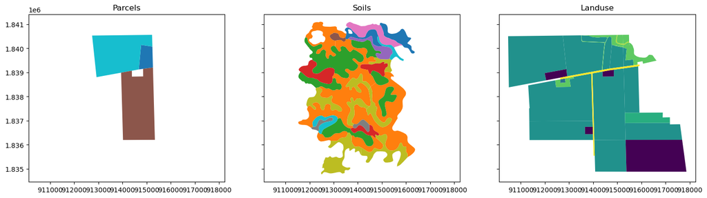

```python
fig, axs = plt.subplots(1,3, figsize=(18,8), sharex=True, sharey=True)

p_df.plot(column='pin', ax=axs[0])
s_df.plot(column='musym', ax=axs[1])
l_df.plot(column='landuse_type', ax=axs[2])

axs[0].set_title('Parcels')
axs[1].set_title('Soils')
axs[2].set_title('Landuse')

plt.show()
```

## Adding Calculated Area

$$ \frac{DeedAc_{part}}{DeedAc_{whole}} = \frac{MeasFt^{2}_{part}}{MeasFt^{2}_{whole}} $$

$$ DeedAc_{part} = DeedAc_{whole} * \frac{MeasFt^{2}_{part}}{MeasFt^{2}_{whole}} $$

```python
p_df['calc_area'] = p_df.area

p_df.head()
```

|  | pin | gross_acres | geometry | calc_area |
| --- | --- | --- | --- | --- |
| 0 | 01-06-200-002 | 11.3698 | POLYGON ((914855.520 1839151.150, 915264.310 1... | 4.981201e+05 |
| 1 | 01-06-200-012 | 73.8963 | POLYGON ((915239.610 1840128.820, 915227.970 1... | 3.220557e+06 |
| 2 | 01-06-200-004 | 84.7479 | POLYGON ((915265.250 1839171.450, 915264.310 1... | 3.714615e+06 |

# Overlay Data

```python
df = gp.overlay(p_df, s_df, how='intersection')
df = gp.overlay(df, l_df, how='intersection')
```

```python
df.explore(column='pin', tiles='CartoDB positron', cmap='Set1', style_kwds={'color':'black'})
```

Make this Notebook Trusted to load map: File -> Trust Notebook

[interactive chart not shown]

### Removing Extra Fields

```python
keepers = [
    'gross_acres',
    'gis_acres',
    'calc_area',
    'pin',
    'soil_type',
    'slope',
    'landuse_type',
    'geometry'
]
```

```python
df.drop(columns=[c for c in df if c not in keepers], inplace=True)

df.sample()
```

|  | pin | gross_acres | calc_area | soil_type | slope | landuse_type | geometry |
| --- | --- | --- | --- | --- | --- | --- | --- |
| 41 | 01-06-200-004 | 84.7479 | 3.714615e+06 | 171 | B1 | 6 | POLYGON ((914855.520 1839151.150, 915158.781 1... |

## Calculate Area of Parts

```python
df[['pin', 'calc_area']].sort_values(by='pin').head()
```

|  | pin | calc_area |
| --- | --- | --- |
| 0 | 01-06-200-002 | 498120.075867 |
| 39 | 01-06-200-002 | 498120.075867 |
| 20 | 01-06-200-002 | 498120.075867 |
| 42 | 01-06-200-002 | 498120.075867 |
| 64 | 01-06-200-002 | 498120.075867 |

```python
df.assign(part_area = df.area)[['pin', 'calc_area', 'part_area']].head()
```

|  | pin | calc_area | part_area |
| --- | --- | --- | --- |
| 0 | 01-06-200-002 | 498120.075867 | 6723.188617 |
| 1 | 01-06-200-002 | 498120.075867 | 27746.888989 |
| 2 | 01-06-200-002 | 498120.075867 | 104054.802763 |
| 3 | 01-06-200-002 | 498120.075867 | 230509.606709 |
| 4 | 01-06-200-002 | 498120.075867 | 95069.736597 |

```python
df.assign(
    part_area = df.area,
    area_ratio = lambda x: x['part_area'] / x['calc_area']
)[['pin', 'calc_area', 'part_area', 'area_ratio']].head()
```

|  | pin | calc_area | part_area | area_ratio |
| --- | --- | --- | --- | --- |
| 0 | 01-06-200-002 | 498120.075867 | 6723.188617 | 0.013497 |
| 1 | 01-06-200-002 | 498120.075867 | 27746.888989 | 0.055703 |
| 2 | 01-06-200-002 | 498120.075867 | 104054.802763 | 0.208895 |
| 3 | 01-06-200-002 | 498120.075867 | 230509.606709 | 0.462759 |
| 4 | 01-06-200-002 | 498120.075867 | 95069.736597 | 0.190857 |

```python
df.assign(
    part_area = df.area,
    area_ratio = lambda x: x['part_area'] / x['calc_area'],
    part_acres = lambda x: x['area_ratio'] * x['gross_acres']
)[['pin', 'calc_area', 'part_area', 'area_ratio', 'gross_acres', 'part_acres']].head()
```

|  | pin | calc_area | part_area | area_ratio | gross_acres | part_acres |
| --- | --- | --- | --- | --- | --- | --- |
| 0 | 01-06-200-002 | 498120.075867 | 6723.188617 | 0.013497 | 11.3698 | 0.153460 |
| 1 | 01-06-200-002 | 498120.075867 | 27746.888989 | 0.055703 | 11.3698 | 0.633334 |
| 2 | 01-06-200-002 | 498120.075867 | 104054.802763 | 0.208895 | 11.3698 | 2.375095 |
| 3 | 01-06-200-002 | 498120.075867 | 230509.606709 | 0.462759 | 11.3698 | 5.261479 |
| 4 | 01-06-200-002 | 498120.075867 | 95069.736597 | 0.190857 | 11.3698 | 2.170007 |

```python
df['part_acres'] = df.area / df['calc_area'] * df['gross_acres']

df
```

|  | pin | gross_acres | calc_area | soil_type | slope | landuse_type | geometry | part_acres |
| --- | --- | --- | --- | --- | --- | --- | --- | --- |
| 0 | 01-06-200-002 | 11.3698 | 4.981201e+05 | 134 | C2 | 2 | POLYGON ((914961.205 1840085.397, 914864.588 1... | 0.153460 |
| 1 | 01-06-200-002 | 11.3698 | 4.981201e+05 | 171 | A1 | 2 | POLYGON ((914754.872 1839903.257, 914854.811 1... | 0.633334 |
| 2 | 01-06-200-002 | 11.3698 | 4.981201e+05 | 171 | B1 | 2 | POLYGON ((914700.494 1839370.687, 914700.494 1... | 2.375095 |
| 3 | 01-06-200-002 | 11.3698 | 4.981201e+05 | 193 | B1 | 2 | POLYGON ((915207.559 1839540.996, 914960.144 1... | 5.261479 |
| 4 | 01-06-200-002 | 11.3698 | 4.981201e+05 | 356 | A1 | 2 | POLYGON ((915235.651 1839257.778, 915245.846 1... | 2.170007 |
| ... | ... | ... | ... | ... | ... | ... | ... | ... |
| 109 | 01-06-200-004 | 84.7479 | 3.714615e+06 | 330 | A1 | 6 | POLYGON ((914009.038 1836786.197, 914007.236 1... | 0.003344 |
| 110 | 01-06-200-004 | 84.7479 | 3.714615e+06 | 154 | A1 | 6 | POLYGON ((914021.459 1836899.001, 914006.305 1... | 0.324633 |
| 111 | 01-06-200-004 | 84.7479 | 3.714615e+06 | 330 | A1 | 6 | POLYGON ((914006.305 1836888.025, 914021.459 1... | 0.017690 |
| 112 | 01-06-200-004 | 84.7479 | 3.714615e+06 | 154 | A1 | 6 | POLYGON ((913999.667 1837061.286, 913995.560 1... | 0.031335 |
| 113 | 01-06-200-004 | 84.7479 | 3.714615e+06 | 330 | A1 | 6 | POLYGON ((914006.305 1836888.025, 914006.977 1... | 0.001058 |

114 rows × 8 columns

# Validating Results

## Checking Acreage Sums

```python
qc = df.groupby('pin').agg({'gross_acres':'max', 'part_acres':'sum'}).reset_index()
qc['diff'] = qc['gross_acres'] - round(qc['part_acres'], 4)

qc
```

|  | pin | gross_acres | part_acres | diff |
| --- | --- | --- | --- | --- |
| 0 | 01-06-200-002 | 11.3698 | 11.369800 | 0.0000 |
| 1 | 01-06-200-004 | 84.7479 | 84.747905 | 0.0000 |
| 2 | 01-06-200-012 | 73.8963 | 73.885566 | 0.0107 |

```python
p_df.query("pin == '01-06-200-012'").overlay(l_df, 'symmetric_difference').explore('pin', tiles=None, cmap='Set1')
```

Make this Notebook Trusted to load map: File -> Trust Notebook

[interactive chart not shown]

## Checking for Valid Landuse

```python
df.query('landuse_type < 0')
```

|  | pin | gross_acres | calc_area | soil_type | slope | landuse_type | geometry | part_acres |
| --- | --- | --- | --- | --- | --- | --- | --- | --- |
| 62 | 01-06-200-004 | 84.7479 | 3.714615e+06 | 171 | B1 | -2 | POLYGON ((914856.975 1838988.859, 914855.836 1... | 0.000643 |
| 63 | 01-06-200-004 | 84.7479 | 3.714615e+06 | 171 | A1 | -2 | POLYGON ((914856.975 1838988.859, 914857.132 1... | 0.000271 |
| 89 | 01-06-200-012 | 73.8963 | 3.220557e+06 | 171 | B1 | -2 | POLYGON ((912922.080 1838840.120, 912890.410 1... | 0.000007 |

# Tidying Up and Exporting

## Dropping Unnecessary Fields

```python
df.drop(columns=['gross_acres', 'calc_area', 'geometry'], inplace=True)
```

## Field Cleanup

### PIN

```python
df.loc[:,'pin'] = df['pin'].str.replace('-', '')

df.sample()
```

|  | pin | soil_type | slope | landuse_type | part_acres |
| --- | --- | --- | --- | --- | --- |
| 83 | 0106200012 | 171 | A1 | 2 | 0.000005 |

### Landuse

```python
df.loc[:, 'landuse_type'] = '0' + df['landuse_type'].astype('str')

df.sample()
```

|  | pin | soil_type | slope | landuse_type | part_acres |
| --- | --- | --- | --- | --- | --- |
| 75 | 0106200004 | 356 | A1 | 06 | 0.235883 |

## Aggregating the Data

```python
out_cols = ['pin', 'soil_type', 'slope', 'landuse_type']

agg_df = df.groupby(by=out_cols, as_index=False).agg({'pin':'first', 'landuse_type':'first', 'slope':'first', 'soil_type':'first', 'part_acres':'sum'})

print(f'Before grouping: {len(df)}', f'After grouping: {len(agg_df)}', sep='\n')

agg_df.head()
```

```
Before grouping: 114
After grouping: 43
```

|  | pin | landuse_type | slope | soil_type | part_acres |
| --- | --- | --- | --- | --- | --- |
| 0 | 0106200002 | 02 | C2 | 134 | 0.153460 |
| 1 | 0106200002 | 04 | C2 | 134 | 0.064840 |
| 2 | 0106200002 | 02 | A1 | 154 | 0.076275 |
| 3 | 0106200002 | 02 | A1 | 171 | 0.633334 |
| 4 | 0106200002 | 02 | B1 | 171 | 2.375095 |

## Rounding and Filtering

```python
agg_df.loc[:, 'part_acres'] = round(agg_df.loc[:, 'part_acres'], 4)

agg_df[agg_df['part_acres'] == 0]
```

|  | pin | landuse_type | slope | soil_type | part_acres |
| --- | --- | --- | --- | --- | --- |
| 31 | 0106200012 | 0-2 | B1 | 171 | 0.0 |

```python
agg_df = agg_df[agg_df.loc[:, 'part_acres'] > 0]
```

## THE FINISH LINE

### (For Kendall County, that is)

```python
agg_df.to_csv(file, sep='\t', header=False)
```

```python
with open(file, 'r') as output:
    print(output.read())
```

```
0	0106200002	02	C2	134	0.1535
1	0106200002	04	C2	134	0.0648
2	0106200002	02	A1	154	0.0763
3	0106200002	02	A1	171	0.6333
4	0106200002	02	B1	171	2.3751
5	0106200002	06	B1	171	0.4146
6	0106200002	02	B1	193	5.2615
7	0106200002	04	B1	193	0.099
8	0106200002	02	A1	356	2.17
9	0106200002	06	A1	356	0.0629
10	0106200002	04	E1	820	0.0588
11	0106200004	02	A1	154	42.7752
12	0106200004	06	A1	154	1.1666
13	0106200004	0-2	A1	171	0.0003
14	0106200004	02	A1	171	13.4167
15	0106200004	06	A1	171	0.1506
16	0106200004	0-2	B1	171	0.0006
17	0106200004	02	B1	171	5.9221
18	0106200004	06	B1	171	0.3641
19	0106200004	02	A1	330	2.8761
20	0106200004	06	A1	330	0.0577
21	0106200004	02	A1	356	17.4916
22	0106200004	06	A1	356	0.5261
23	0106200012	02	C2	134	2.6682
24	0106200012	04	C2	134	2.3011
25	0106200012	02	A1	154	18.9084
26	0106200012	04	A1	154	0.2648
27	0106200012	06	A1	154	0.8826
28	0106200012	02	A1	171	33.1243
29	0106200012	04	A1	171	0.6924
30	0106200012	06	A1	171	0.3116
32	0106200012	02	B1	171	3.5001
33	0106200012	04	B1	171	0.1389
34	0106200012	06	B1	171	0.2376
35	0106200012	02	B1	193	3.3188
36	0106200012	04	B1	193	0.1702
37	0106200012	02	A1	233	2.4464
38	0106200012	02	A1	3082	0.0002
39	0106200012	04	A1	3082	2.841
40	0106200012	05	A1	3082	0.5009
41	0106200012	02	A1	356	0.6229
42	0106200012	04	E1	820	0.9551
```

# Doing the Valuation, too!

### Soil Productivity Index ($PI$)

```python
pi_df = pd.read_csv('resources/soil_PI_2021.csv')

pi_df.head()
```

|  | map_symbol | soil_type | favorability | productivity_index |
| --- | --- | --- | --- | --- |
| 0 | 2 | Cisne silt loam | Favorable | 97.0 |
| 1 | 3 | Hoyleton silt loam | Favorable | 96.0 |
| 2 | 4 | Richview silt loam | Favorable | 98.0 |
| 3 | 5 | Blair silt loam | Unfavorable | 92.0 |
| 4 | 6 | Fishhook silt loam | Unfavorable | 86.0 |

### Slope and Erosion Coefficients

Though there is a full table of PI adjustments for each 1% from 0 to 43, we don't have the slope values in such detail. Working with NRCS soil data, we have the following classes based on the map symbol's slope letter:

| Letter Code | % Slope |
| --- | --- |
| None / A | 0-2% |
| B | 2-5% |
| C | 5-10% |
| D | 10-15% |
| E | 15-18% |
| F | 18-35% |
| G | 35-70% |

Per Pub 122:

> Because Table 3 cannot be used with slope ranges, use a central point of the slope ranges unless a better determinant of slope is available.

For our case, we'll use a central value of each class to determine the coefficient to apply to the PI.

```python
se_df = pd.read_csv('resources/soil_slope_erosion_2021.csv')

se_df.head()
```

|  | erosion_code | slope_desc | eros_desc | coeff_fav | coeff_unf |
| --- | --- | --- | --- | --- | --- |
| 0 | A | 0-2% | UNERODED | 1.00 | 1.00 |
| 1 | A1 | 0-2% | UNERODED | 1.00 | 1.00 |
| 2 | A2 | 0-2% | MODERATE | 0.96 | 0.93 |
| 3 | A3 | 0-2% | SEVERE | 0.88 | 0.78 |
| 4 | B | 2-5% | UNERODED | 0.99 | 0.98 |

### Merge DataFrames

#### Productivity Index

```python
val_df = agg_df.merge(pi_df, how='left', left_on='soil_type', right_on='map_symbol', suffixes=('','_desc'))

val_df.head()
```

|  | pin | landuse_type | slope | soil_type | part_acres | map_symbol | soil_type_desc | favorability | productivity_index |
| --- | --- | --- | --- | --- | --- | --- | --- | --- | --- |
| 0 | 0106200002 | 02 | C2 | 134 | 0.1535 | 134 | Camden silt loam | Favorable | 106.0 |
| 1 | 0106200002 | 04 | C2 | 134 | 0.0648 | 134 | Camden silt loam | Favorable | 106.0 |
| 2 | 0106200002 | 02 | A1 | 154 | 0.0763 | 154 | Flanagan silt loam | Favorable | 127.0 |
| 3 | 0106200002 | 02 | A1 | 171 | 0.6333 | 171 | Catlin silt loam | Favorable | 122.0 |
| 4 | 0106200002 | 02 | B1 | 171 | 2.3751 | 171 | Catlin silt loam | Favorable | 122.0 |

#### Slope and Erosion

```python
val_df = val_df.merge(se_df, how='left', left_on='slope', right_on='erosion_code')

val_df.head()
```

|  | pin | landuse_type | slope | soil_type | part_acres | map_symbol | soil_type_desc | favorability | productivity_index | erosion_code | slope_desc | eros_desc | coeff_fav | coeff_unf |
| --- | --- | --- | --- | --- | --- | --- | --- | --- | --- | --- | --- | --- | --- | --- |
| 0 | 0106200002 | 02 | C2 | 134 | 0.1535 | 134 | Camden silt loam | Favorable | 106.0 | C2 | 5-10% | MODERATE | 0.92 | 0.88 |
| 1 | 0106200002 | 04 | C2 | 134 | 0.0648 | 134 | Camden silt loam | Favorable | 106.0 | C2 | 5-10% | MODERATE | 0.92 | 0.88 |
| 2 | 0106200002 | 02 | A1 | 154 | 0.0763 | 154 | Flanagan silt loam | Favorable | 127.0 | A1 | 0-2% | UNERODED | 1.00 | 1.00 |
| 3 | 0106200002 | 02 | A1 | 171 | 0.6333 | 171 | Catlin silt loam | Favorable | 122.0 | A1 | 0-2% | UNERODED | 1.00 | 1.00 |
| 4 | 0106200002 | 02 | B1 | 171 | 2.3751 | 171 | Catlin silt loam | Favorable | 122.0 | B1 | 2-5% | UNERODED | 0.99 | 0.98 |

### Adusted $PI$

```python
val_df.insert(
    5,
    'adj_PI',
    np.where(
        val_df['favorability']=='Favorable',
        val_df['productivity_index'] * val_df['coeff_fav'],
        val_df['productivity_index'] * val_df['coeff_unf']
    )
)

val_df.head()
```

|  | pin | landuse_type | slope | soil_type | part_acres | adj_PI | map_symbol | soil_type_desc | favorability | productivity_index | erosion_code | slope_desc | eros_desc | coeff_fav | coeff_unf |
| --- | --- | --- | --- | --- | --- | --- | --- | --- | --- | --- | --- | --- | --- | --- | --- |
| 0 | 0106200002 | 02 | C2 | 134 | 0.1535 | 97.52 | 134 | Camden silt loam | Favorable | 106.0 | C2 | 5-10% | MODERATE | 0.92 | 0.88 |
| 1 | 0106200002 | 04 | C2 | 134 | 0.0648 | 97.52 | 134 | Camden silt loam | Favorable | 106.0 | C2 | 5-10% | MODERATE | 0.92 | 0.88 |
| 2 | 0106200002 | 02 | A1 | 154 | 0.0763 | 127.00 | 154 | Flanagan silt loam | Favorable | 127.0 | A1 | 0-2% | UNERODED | 1.00 | 1.00 |
| 3 | 0106200002 | 02 | A1 | 171 | 0.6333 | 122.00 | 171 | Catlin silt loam | Favorable | 122.0 | A1 | 0-2% | UNERODED | 1.00 | 1.00 |
| 4 | 0106200002 | 02 | B1 | 171 | 2.3751 | 120.78 | 171 | Catlin silt loam | Favorable | 122.0 | B1 | 2-5% | UNERODED | 0.99 | 0.98 |

### Merge in the Equalized Assessed Value

Let's bring in *another* table. **Table 1** from Pub 122 contains the certified per-acre EAV for a given productivity index. And don't be fooled by table 1's headers!

Even though the second to last column is titled **Equalized Assessed Value** (something you might shorten to, y'know, *E-A-V*), whenever Publication 122 makes reference to an EAV in their instructions, they are referring to the **Certified Value**.

```python
eav_df = pd.read_csv('resources/eav_2021.csv')

eav_df.head()
```

|  | avg_PI | eav |
| --- | --- | --- |
| 0 | 82 | 199.29 |
| 1 | 83 | 200.90 |
| 2 | 84 | 202.51 |
| 3 | 85 | 204.18 |
| 4 | 86 | 205.86 |

### $PI < 82$

For a low PI of $PI_{n}$ under the minimum certified PI $PI_{min}$:

$$ EAV^{PI_{n}} = EAV^{PI_{min}} - \left(\frac{EAV^{PI_{min+5}} - EAV^{PI_{min}}}{5} * (min - n)\right) \vee \frac{EAV^{PI_{min}}}{3} $$

Whichever is greater.

Put in the certified 2021 values, this would be: $$ EAV^{PI_{n}} = 199.29 - \left(\frac{207.47 - 199.29}{5} * (82 - n)\right) \vee \frac{199.29}{3} $$

### Populating the Sub-82 Values

```python
sub82 = pd.DataFrame({'avg_PI': np.arange(1,82)})

sub82['eav'] = 199.29 - (((207.47-199.29)/5)*(82-sub82['avg_PI']))

print(f'Floor: {199.29/3:0.5}')

sub82.head()
```

```
Floor: 66.43
```

|  | avg_PI | eav |
| --- | --- | --- |
| 0 | 1 | 66.774 |
| 1 | 2 | 68.410 |
| 2 | 3 | 70.046 |
| 3 | 4 | 71.682 |
| 4 | 5 | 73.318 |

#### Append New Values to the EAV Table

```python
eav_df = eav_df.append(sub82)
```

```python
val_df.loc[:,'adj_PI'] = val_df.loc[:,'adj_PI'].round()

val_df = val_df.merge(eav_df, how='left', left_on='adj_PI', right_on='avg_PI')

val_df.head()
```

|  | pin | landuse_type | slope | soil_type | part_acres | adj_PI | map_symbol | soil_type_desc | favorability | productivity_index | erosion_code | slope_desc | eros_desc | coeff_fav | coeff_unf | avg_PI | eav |
| --- | --- | --- | --- | --- | --- | --- | --- | --- | --- | --- | --- | --- | --- | --- | --- | --- | --- |
| 0 | 0106200002 | 02 | C2 | 134 | 0.1535 | 98.0 | 134 | Camden silt loam | Favorable | 106.0 | C2 | 5-10% | MODERATE | 0.92 | 0.88 | 98.0 | 272.79 |
| 1 | 0106200002 | 04 | C2 | 134 | 0.0648 | 98.0 | 134 | Camden silt loam | Favorable | 106.0 | C2 | 5-10% | MODERATE | 0.92 | 0.88 | 98.0 | 272.79 |
| 2 | 0106200002 | 02 | A1 | 154 | 0.0763 | 127.0 | 154 | Flanagan silt loam | Favorable | 127.0 | A1 | 0-2% | UNERODED | 1.00 | 1.00 | 127.0 | 768.46 |
| 3 | 0106200002 | 02 | A1 | 171 | 0.6333 | 122.0 | 171 | Catlin silt loam | Favorable | 122.0 | A1 | 0-2% | UNERODED | 1.00 | 1.00 | 122.0 | 585.30 |
| 4 | 0106200002 | 02 | B1 | 171 | 2.3751 | 121.0 | 171 | Catlin silt loam | Favorable | 122.0 | B1 | 2-5% | UNERODED | 0.99 | 0.98 | 121.0 | 541.03 |

### Apply Landuse Coefficients

$Cropland = EAV*1$

$Permanent Pasture = \frac{EAV}{3}$

$Other Farmland = \frac{EAV}{6}$

For **contributory wasteland**, we assess the land at 1/6 of the EAV of the *lowest PI of cropland certified by IDR*, which for 2021, happens to be **82**. This results in an EAV of **$33.22**.

#### Create and Populate New Field

```python
val_df.insert(
    6,
    'eav_adj',
    np.where(
        val_df['landuse_type'] == '02',
        val_df['eav'],
        0
    )
)
```

#### Calculations

```python
# permanent pasture
val_df.loc[val_df['landuse_type']=='03', 'eav_adj'] = val_df['eav']/3

# other farmland
val_df.loc[val_df['landuse_type']=='04', 'eav_adj'] = val_df['eav']/6

# contributory wasteland
val_df.loc[val_df['landuse_type'] == '05', 'eav_adj'] = 33.22
```

```python
val_df[['landuse_type', 'eav', 'eav_adj']].sample(5)
```

|  | landuse_type | eav | eav_adj |
| --- | --- | --- | --- |
| 1 | 04 | 272.79 | 45.465 |
| 3 | 02 | 585.30 | 585.300 |
| 27 | 06 | 768.46 | 0.000 |
| 25 | 02 | 768.46 | 768.460 |
| 17 | 02 | 541.03 | 541.030 |

### Multiply Adjusted EAV by Acres

```python
val_df['value'] = val_df['part_acres'] * val_df['eav_adj']

val_df[['pin', 'soil_type', 'slope', 'landuse_type', 'part_acres', 'value']].fillna(0).sample(5)
```

|  | pin | soil_type | slope | landuse_type | part_acres | value |
| --- | --- | --- | --- | --- | --- | --- |
| 10 | 0106200002 | 820 | E1 | 04 | 0.0588 | 1.776681 |
| 36 | 0106200012 | 233 | A1 | 02 | 2.4464 | 888.459088 |
| 27 | 0106200012 | 154 | A1 | 06 | 0.8826 | 0.000000 |
| 5 | 0106200002 | 171 | B1 | 06 | 0.4146 | 0.000000 |
| 0 | 0106200002 | 134 | C2 | 02 | 0.1535 | 41.873265 |

# Extending the Process

There are **lots** of ways this could be further developed and tailored to other situations, not limited to:

1. Creating a standalone `farms.py` script that takes a list of PINs as a parameter
2. Wrapping the whole thing in a GUI for non-developers to use
3. Loading it into something like AWS Lambda or Azure Functions to trigger the script through an API call
4. Generating per-parcel PDFs with a map and table of values